# Titanic Data Explanation

September 12, 2018

## Historical Introduction

The history and the data that we have in this presentation is about the disaster of the Titanic. The Titanic was a British passenger liner that sank in the North Atlantic Ocean in the early hours of 15 April 1912, after colliding with an iceberg during its maiden voyage from Southampton to New York City.

Route: Southampton to New York City

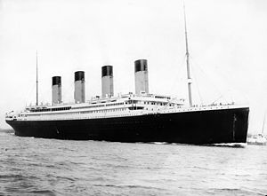

## Introduction

In this project we are going to analize a data set of the titanic that we have and we are going to make the data analysis in a language R and I'm going to use CSS to give some style to the presentation. Just to introduce yourself to the dataset and the analysis, There were a total 2224 persons and there were lifeboats for only 1178 people. Therefore 1500 people died out of 2224. This is not just a movie but a real story of Titanic ship that crashed in April, 1912.

## Exploring the Dataset

**Let's see the data that we have and the characteristics that we have.**

```
##   PassengerId Survived Pclass                    Name  Sex Age SibSp Parch
## 1           1        0      3 Braund, Mr. Owen Harris male  22     1     0
##      Ticket Fare Cabin Embarked
## 1 A/5 21171 7.25              S
```

## Exploring the Dataset

**Let's see the data that we have and the structure of the data**

```
## 'data.frame':    891 obs. of  12 variables:
##  $ PassengerId: int  1 2 3 4 5 6 7 8 9 10 ...
##  $ Survived   : int  0 1 1 1 0 0 0 0 1 1 ...
##  $ Pclass     : int  3 1 3 1 3 3 1 3 3 2 ...
##  $ Name       : Factor w/ 891 levels "Abbing, Mr. Anthony",..: 109 191 358 277 16 559 520 629 417 581 ...
##  $ Sex        : Factor w/ 2 levels "female","male": 2 1 1 1 2 2 2 2 1 1 ...
##  $ Age        : num  22 38 26 35 35 NA 54 2 27 14 ...
##  $ SibSp      : int  1 1 0 1 0 0 0 3 0 1 ...
##  $ Parch      : int  0 0 0 0 0 0 0 1 2 0 ...
##  $ Ticket     : Factor w/ 681 levels "110152","110413",..: 524 597 670 50 473 276 86 396 345 133 ...
##  $ Fare       : num  7.25 71.28 7.92 53.1 8.05 ...
##  $ Cabin      : Factor w/ 148 levels "","A10","A14",..: 1 83 1 57 1 1 131 1 1 1 ...
##  $ Embarked   : Factor w/ 4 levels "","C","Q","S": 4 2 4 4 4 3 4 4 4 2 ...
```

## Exploring the Dataset

**Let's see now the missing data**

```
## PassengerId    Survived      Pclass        Name         Sex         Age
##           0           0           0           0           0         177
##       SibSp       Parch      Ticket        Fare       Cabin    Embarked
##           0           0           0           0           0           0
```

## Trying to solve the mising data

```
## PassengerId    Survived      Pclass        Name         Sex         Age
##           0           0           0           0           0          NA
##       SibSp       Parch      Ticket        Fare       Cabin    Embarked
##           0           0           0           0         687           2
```

## Let's going to work with this now

```
## 'data.frame':    891 obs. of  12 variables:
##  $ PassengerId: int  1 2 3 4 5 6 7 8 9 10 ...
##  $ Survived   : Factor w/ 2 levels "0","1": 1 2 2 2 1 1 1 1 2 2 ...
##  $ Pclass     : Factor w/ 3 levels "1","2","3": 3 1 3 1 3 3 1 3 3 2 ...
##  $ Name       : Factor w/ 891 levels "Abbing, Mr. Anthony",..: 109 191 358 277 16 559 520 629 417 581 ...
##  $ Sex        : Factor w/ 2 levels "female","male": 2 1 1 1 2 2 2 2 1 1 ...
##  $ Age        : num  22 38 26 35 35 NA 54 2 27 14 ...
##  $ SibSp      : int  1 1 0 1 0 0 0 3 0 1 ...
##  $ Parch      : int  0 0 0 0 0 0 0 1 2 0 ...
##  $ Ticket     : Factor w/ 681 levels "110152","110413",..: 524 597 670 50 473 276 86 396 345 133 ...
##  $ Fare       : num  7.25 71.28 7.92 53.1 8.05 ...
##  $ Cabin      : Factor w/ 148 levels "","A10","A14",..: 1 83 1 57 1 1 131 1 1 1 ...
##  $ Embarked   : Factor w/ 4 levels "","C","Q","S": 4 2 4 4 4 3 4 4 4 2 ...
```

## Characteristics of the Dataset

-PassengerId: Id of every passenger  
-Survived: If a passenger survived has 1 and 0 if It didn't  
-Pclass: We have 3 classes of passengers. Class: 1, 2 and 3  
-Name: The name of the passenger  
-Sex: The gender of the passenger  
-Age: Age of passenger.  
-SibSp: Indication that passenger have siblings and spouse.  
-Parch: Whether a passenger is alone or have family.

## Characteristics of the Dataset

-Ticket: Ticket no of passenger.  
-Fare: Indicating the fare.  
-Cabin: The cabin of passenger.  
-Embarked: Port of embarkation. C = Cherbourg, Q = Queenstown, S = Southampton

## Summary of the dataset

```
##   PassengerId    Survived Pclass
##  Min.   :  1.0   0:549    1:216
##  1st Qu.:223.5   1:342    2:184
##  Median :446.0            3:491
##  Mean   :446.0
##  3rd Qu.:668.5
##  Max.   :891.0
##
##                                     Name         Sex           Age
##  Abbing, Mr. Anthony                  :  1   female:314   Min.   : 0.42
##  Abbott, Mr. Rossmore Edward          :  1   male  :577   1st Qu.:20.12
##  Abbott, Mrs. Stanton (Rosa Hunt)     :  1                Median :28.00
##  Abelson, Mr. Samuel                  :  1                Mean   :29.70
##  Abelson, Mrs. Samuel (Hannah Wizosky):  1                3rd Qu.:38.00
##  Adahl, Mr. Mauritz Nils Martin       :  1                Max.   :80.00
##  (Other)                              :885                NA's   :177
##      SibSp           Parch             Ticket         Fare
##  Min.   :0.000   Min.   :0.0000   1601    :  7   Min.   :  0.00
##  1st Qu.:0.000   1st Qu.:0.0000   347082  :  7   1st Qu.:  7.91
##  Median :0.000   Median :0.0000   CA. 2343:  7   Median : 14.45
##  Mean   :0.523   Mean   :0.3816   3101295 :  6   Mean   : 32.20
##  3rd Qu.:1.000   3rd Qu.:0.0000   347088  :  6   3rd Qu.: 31.00
##  Max.   :8.000   Max.   :6.0000   CA 2144 :  6   Max.   :512.33
##                                   (Other) :852
##          Cabin     Embarked
##             :687    :  0
##  B96 B98    :  4   C:170
##  C23 C25 C27:  4   Q: 77
##  G6         :  4   S:644
##  C22 C26    :  3
##  D          :  3
##  (Other)    :186
```

## Summary of Passenger ID

```
##    Min. 1st Qu.  Median    Mean 3rd Qu.    Max.
##     1.0   223.5   446.0   446.0   668.5   891.0
```

## Summary of Survivors

```
##   0   1
## 549 342
```

## Summary of Passengers class

```
##   1   2   3
## 216 184 491
```

## Summary of Passengers Sex

[output not shown]

## Summary of Passengers Age

```
##    Min. 1st Qu.  Median    Mean 3rd Qu.    Max.    NA's
##    0.42   20.12   28.00   29.70   38.00   80.00     177
```

## Summary of Passengers Fare

```
##    Min. 1st Qu.  Median    Mean 3rd Qu.    Max.
##    0.00    7.91   14.45   32.20   31.00  512.33
```

## Summary of Passengers Port of embarkation

```
##       C   Q   S
##   0 170  77 644
```

## Boxplot of Passengers Age

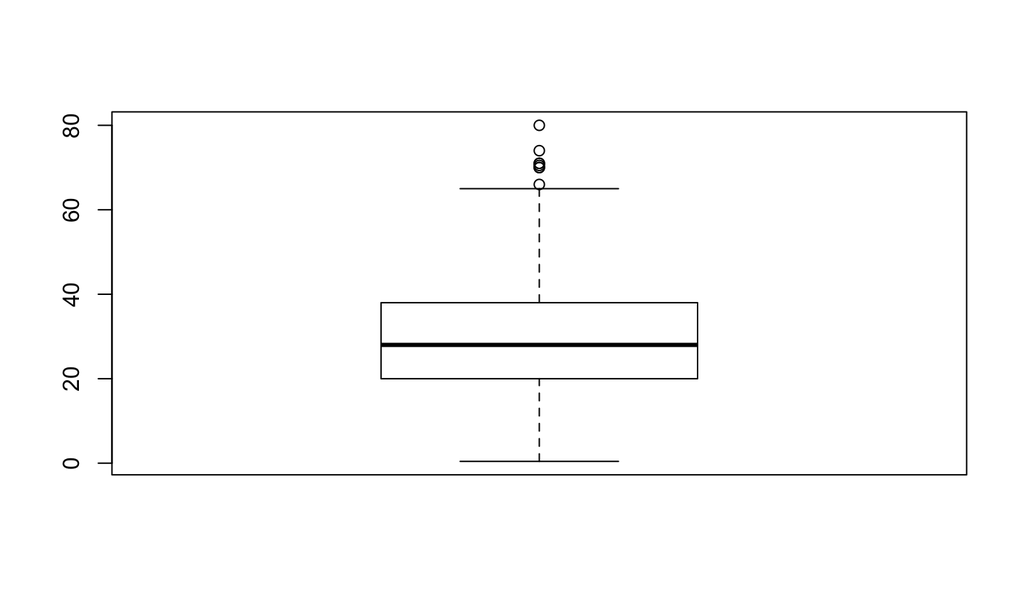

## Boxplot of Passengers Fare

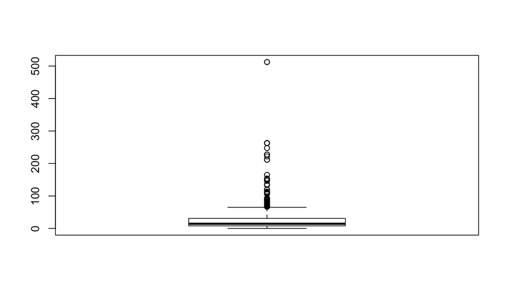

## Histogram of Passengers age

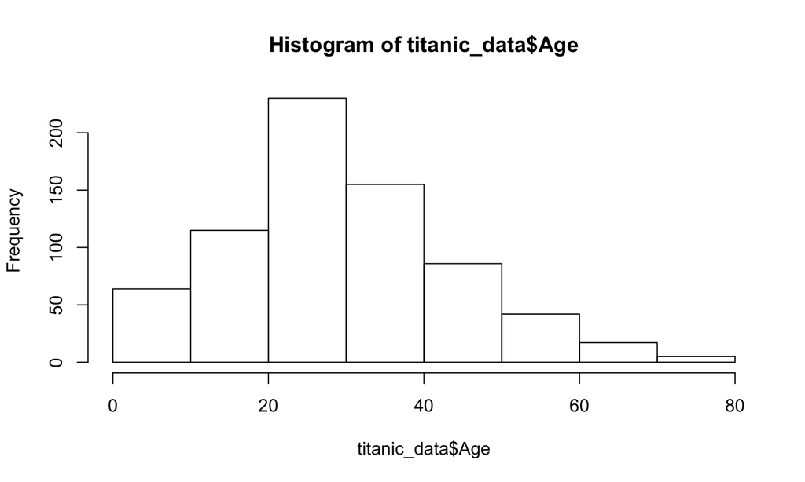